# Comparison of bias correction methods for TRMM calibration with respect to extreme precipitation events over Iberian Peninsula during 1998-2010

```r
plot(density(obs.mallorca$Data, na.rm = TRUE),
main = "Obs, TRMM and Scaling cal. density function",
xlab = "Precip amount (mm)")
grid()
```

```r
lines(density(trmm.mallorca$Data, na.rm = TRUE), col = "red")
lines(density(cal.mallorca.scaling$Data, na.rm = TRUE), col = "blue")
```

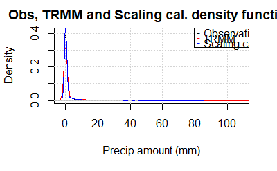

```r
legend("topright", legend = c("Observation","TRMM", "Scaling calibration"), pch ='-', col = c("black", "red", "blue"))
```

```r
qqplot(obs.mallorca$Data, trmm.mallorca$Data, main = "Obs,TRMM and Scaling calibration QQplot", xlab = "Observed (mm)", ylab = "TRMM/Calibration (mm)", col = "red")

abline(a = 0, b = 1)
```

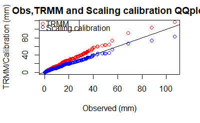

```r
points(sort(obs.mallorca$Data), sort(cal.mallorca.scaling$Data), col = "blue")

legend("topleft", legend = c("TRMM", "Scaling calibration"), pch = 1, col = c("red", "blue"))
```

```r
plot(density(obs.mallorca$Data, na.rm = TRUE),
main = "Obs, TRMM and EQM cal. density function",
xlab = "Precip amount (mm)")
grid()
```

```r
lines(density(trmm.mallorca$Data, na.rm = TRUE), col = "red")
lines(density(cal.mallorca.eqm$Data, na.rm = TRUE), col = "blue")
```

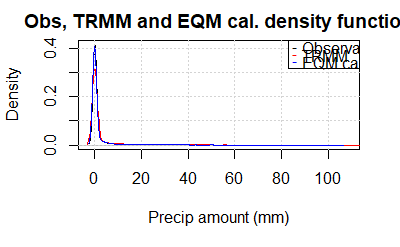

```r
legend("topright", legend = c("Observation","TRMM", "EQM calibration"), pch ='-', col = c("black", "red", "blue"))
```

```r
qqplot(obs.mallorca$Data, trmm.mallorca$Data, main = "Obs,TRMM and EQM calibration QQplot", xlab = "Observed (mm)", ylab = "TRMM/Calibration (mm)", col = "red")

abline(a = 0, b = 1)
```

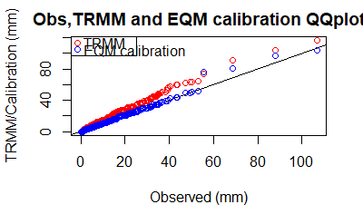

```r
points(sort(obs.mallorca$Data), sort(cal.mallorca.eqm$Data), col = "blue")

legend("topleft", legend = c("TRMM", "EQM calibration"), pch = 1, col = c("red", "blue"))
```

```r
plot(density(obs.mallorca$Data, na.rm = TRUE),
main = "Obs, TRMM and EQM extrapol cal. density function",
xlab = "Precip amount (mm)")
grid()
```

```r
lines(density(trmm.mallorca$Data, na.rm = TRUE), col = "red")
lines(density(cal.mallorca.eqm.extrapol$Data, na.rm = TRUE), col = "blue")
```

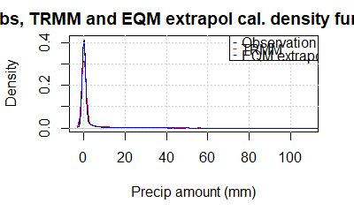

```r
legend("topright", legend = c("Observation","TRMM", "EQM extrapol calibration"), pch ='-', col = c("black", "red", "blue"))
```

```r
qqplot(obs.mallorca$Data, trmm.mallorca$Data, main = "Obs,TRMM and EQM extrapol calibration QQplot", xlab = "Observed (mm)", ylab = "TRMM/Calibration (mm)", col = "red")

abline(a = 0, b = 1)
```

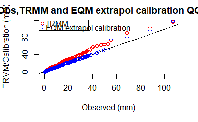

```r
points(sort(obs.mallorca$Data), sort(cal.mallorca.eqm.extrapol$Data), col = "blue")

legend("topleft", legend = c("TRMM", "EQM extrapol calibration"), pch = 1, col = c("red", "blue"))
```

```r
plot(density(obs.mallorca$Data, na.rm = TRUE),
main = "Obs, TRMM and PQM cal. density function",
xlab = "Precip amount (mm)")
grid()
```

```r
lines(density(trmm.mallorca$Data, na.rm = TRUE), col = "red")
lines(density(cal.mallorca.pqm$Data, na.rm = TRUE), col = "blue")
```

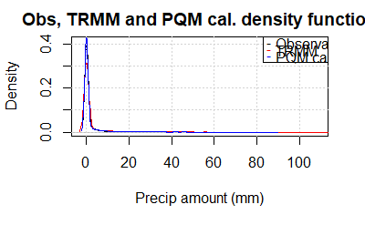

```r
legend("topright", legend = c("Observation","TRMM", "PQM calibration"), pch ='-', col = c("black", "red", "blue"))
```

```r
qqplot(obs.mallorca$Data, trmm.mallorca$Data, main = "Obs,TRMM and PQM calibration QQplot", xlab = "Observed (mm)", ylab = "TRMM/Calibration (mm)", col = "red")

abline(a = 0, b = 1)
```

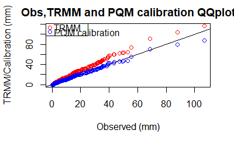

```r
points(sort(obs.mallorca$Data), sort(cal.mallorca.pqm$Data), col = "blue")

legend("topleft", legend = c("TRMM", "PQM calibration"), pch = 1, col = c("red", "blue"))
```

```r
plot(density(obs.mallorca$Data, na.rm = TRUE),
main = "Obs, TRMM and GPQM cal. density function",
xlab = "Precip amount (mm)")
grid()
```

```r
lines(density(trmm.mallorca$Data, na.rm = TRUE), col = "red")
lines(density(cal.mallorca.gpqm$Data, na.rm = TRUE), col = "blue")
```

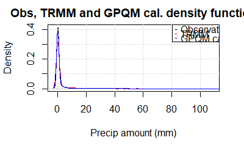

```r
legend("topright", legend = c("Observation","TRMM", "GPQM calibration"), pch ='-', col = c("black", "red", "blue"))
```

```r
qqplot(obs.mallorca$Data, trmm.mallorca$Data, main = "Obs,TRMM and GPQM calibration QQplot", xlab = "Observed (mm)", ylab = "TRMM/Calibration (mm)", col = "red")

abline(a = 0, b = 1)
```

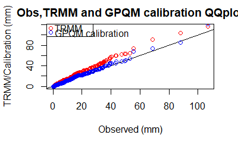

```r
points(sort(obs.mallorca$Data), sort(cal.mallorca.gpqm$Data), col = "blue")

legend("topleft", legend = c("TRMM", "GPQM calibration"), pch = 1, col = c("red", "blue"))
```

One more time, EQM gets the best results in all of the index computed. The results are quite good, showing that the calibration matters and is necessary. The performance of the other calibration methods compared to TRMM is quite good too, with the exception of the values for P98WetAmount in general. Also, the value obtained with GPQM calibration in P98Wet Index is really poor(worse than TRMM).

# SAN SEBASTIÁN-IGUELDO

Same with San Sebastián-Igueldo station.

```r
obs.sansebastian <- subsetGrid(obs, station.id = obs$Metadata$station_id[6])
idx <- which.min(abs(trmm$xyCoords$x - obs.sansebastian$xyCoords$x))
lon <- trmm$xyCoords$x[idx]

idx2 <- which.min(abs(trmm$xyCoords$y - obs.sansebastian$xyCoords$y))
lat <- trmm$xyCoords$y[idx2]

trmm.sansebastian <- subsetGrid(trmm, lonLim = lon, latLim = lat)

index.obs.sansebastian <- valueIndex1D(obs.sansebastian$Data,index.codes=c("Skewness","R10","R10p","R20","R20p","P98Wet","P98WetAmount"))

index.trmm.sansebastian <- valueIndex1D(trmm.sansebastian$Data,index.codes=c("Skewness","R10","R10p","R20","R20p","P98Wet","P98WetAmount"))

index.obs.sansebastian.rv13max <- MaxReturnValue(obs.sansebastian)
index.trmm.sansebastian.rv13max <- MaxReturnValue(trmm.sansebastian)


cal.sansebastian.scaling <- biasCorrection(y = obs.sansebastian, x = trmm.sansebastian, newdata = trmm.sansebastian, precipitation = TRUE, cross.val = "loo", method = "scaling", scaling.type = "multiplicative")

cal.sansebastian.scaling$Dates$start <- as.POSIXct(cal.sansebastian.scaling$Dates$start,tz = "GMT")
cal.sansebastian.scaling$Dates$end <- as.POSIXct(cal.sansebastian.scaling$Dates$end,tz = "GMT")

index.cal.sansebastian.scaling.rv13max <- MaxReturnValue(cal.sansebastian.scaling)


index.cal.sansebastian.scaling <- valueIndex1D(cal.sansebastian.scaling$Data,index.codes=c("Skewness","R10","R10p","R20","R20p","P98Wet","P98WetAmount"))

cal.sansebastian.eqm <- biasCorrection(y = obs.sansebastian, x = trmm.sansebastian, newdata = trmm.sansebastian, precipitation = TRUE, cross.val = "loo", method = "eqm")

cal.sansebastian.eqm$Dates$start <- as.POSIXct(cal.sansebastian.eqm$Dates$start,tz = "GMT")
cal.sansebastian.eqm$Dates$end <- as.POSIXct(cal.sansebastian.eqm$Dates$end,tz = "GMT")

index.cal.sansebastian.eqm.rv13max <- MaxReturnValue(cal.sansebastian.eqm)



index.cal.sansebastian.eqm <- valueIndex1D(cal.sansebastian.eqm$Data,index.codes=c("Skewness","R10","R10p","R20","R20p","P98Wet","P98WetAmount"))

cal.sansebastian.eqm.extrapol <- biasCorrection(y = obs.sansebastian, x = trmm.sansebastian, newdata = trmm.sansebastian, precipitation = TRUE, cross.val = "loo", method = "eqm", extrapolation = "constant")

cal.sansebastian.eqm.extrapol$Dates$start <- as.POSIXct(cal.sansebastian.eqm.extrapol$Dates$start,tz = "GMT")
cal.sansebastian.eqm.extrapol$Dates$end <- as.POSIXct(cal.sansebastian.eqm.extrapol$Dates$end,tz = "GMT")

index.cal.sansebastian.eqm.extrapol.rv13max <- MaxReturnValue(cal.sansebastian.eqm.extrapol)



index.cal.sansebastian.eqm.extrapol <- valueIndex1D(cal.sansebastian.eqm.extrapol$Data,index.codes=c("Skewness","R10","R10p","R20","R20p","P98Wet","P98WetAmount"))

cal.sansebastian.pqm <- biasCorrection(y = obs.sansebastian, x = trmm.sansebastian, newdata = trmm.sansebastian, precipitation = TRUE, cross.val = "loo", method = "pqm",  fitdistr.args = list(densfun = "gamma"))

cal.sansebastian.pqm$Dates$start <- as.POSIXct(cal.sansebastian.pqm$Dates$start,tz = "GMT")
cal.sansebastian.pqm$Dates$end <- as.POSIXct(cal.sansebastian.pqm$Dates$end,tz = "GMT")

index.cal.sansebastian.pqm.rv13max <- MaxReturnValue(cal.sansebastian.pqm)


index.cal.sansebastian.pqm <- valueIndex1D(cal.sansebastian.pqm$Data,index.codes=c("Skewness","R10","R10p","R20","R20p","P98Wet","P98WetAmount"))

cal.sansebastian.gpqm <- biasCorrection(y = obs.sansebastian, x = trmm.sansebastian, newdata = trmm.sansebastian, precipitation = TRUE, cross.val = "loo", method = "gpqm", theta = 0.7)
```

[output not shown]

```r
cal.sansebastian.gpqm$Dates$start <- as.POSIXct(cal.sansebastian.gpqm$Dates$start,tz = "GMT")
cal.sansebastian.gpqm$Dates$end <- as.POSIXct(cal.sansebastian.gpqm$Dates$end,tz = "GMT")

index.cal.sansebastian.gpqm.rv13max <- MaxReturnValue(cal.sansebastian.gpqm)



index.cal.sansebastian.gpqm <- valueIndex1D(cal.sansebastian.gpqm$Data,index.codes=c("Skewness","R10","R10p","R20","R20p","P98Wet","P98WetAmount"))
```

```r
index.obs.sansebastian <- c(index.obs.sansebastian,index.obs.sansebastian.rv13max)
index.trmm.sansebastian <- c(index.trmm.sansebastian,index.trmm.sansebastian.rv13max)
index.cal.sansebastian.scaling <- c(index.cal.sansebastian.scaling,index.cal.sansebastian.scaling.rv13max)
index.cal.sansebastian.eqm <- c(index.cal.sansebastian.eqm,index.cal.sansebastian.eqm.rv13max)
index.cal.sansebastian.eqm.extrapol <- c(index.cal.sansebastian.eqm.extrapol,index.cal.sansebastian.eqm.extrapol.rv13max)
index.cal.sansebastian.pqm <- c(index.cal.sansebastian.pqm,index.cal.sansebastian.pqm.rv13max)
index.cal.sansebastian.gpqm <- c(index.cal.sansebastian.gpqm,index.cal.sansebastian.gpqm.rv13max)

results.sansebastian <- data.frame(index.obs.sansebastian, index.trmm.sansebastian, index.cal.sansebastian.scaling,
                      index.cal.sansebastian.eqm,index.cal.sansebastian.eqm.extrapol, index.cal.sansebastian.pqm, index.cal.sansebastian.gpqm
                      )
colnames(results.sansebastian) <- c("Obs","TRMM","Scaling cal.", "EQM cal.","EQM extrapol cal.", "PQM cal.","GPQM cal.")

results.sansebastian <- format(results.sansebastian, digits = 3, scientific = 5)

results.sansebastian
```

|  | Obs | TRMM | Scaling cal. | EQM cal. | EQM extrapol cal. | PQM cal. | GPQM cal. |
| --- | --- | --- | --- | --- | --- | --- | --- |
| Skewness | 4.1927 | 4.7991 | 4.7728 | 4.5337 | 4.5943 | 4.4815 | 4.1930 |
| R10 | 0.1358 | 0.0857 | 0.1120 | 0.1177 | 0.1182 | 0.0977 | 0.0857 |
| R10p | 13701.3000 | 10636.5292 | 17470.9897 | 12816.5473 | 12844.7858 | 12397.4250 | 8571.4487 |
| R20 | 0.0539 | 0.0442 | 0.0691 | 0.0545 | 0.0545 | 0.0522 | 0.0350 |
| R20p | 8234.4000 | 7805.4113 | 14620.5515 | 8383.2492 | 8388.8822 | 9279.7376 | 5299.2173 |
| P98Wet | 44.2820 | 60.5752 | 91.0935 | 49.9084 | 49.9084 | 64.0091 | 45.9789 |
| P98WetAmount | 2117.1000 | 1327.7941 | 2066.9626 | 1315.0199 | 1320.6529 | 1451.7941 | 979.8940 |
| WetAnnualMaxSpell | 11.0000 | 4.0000 | 4.0000 | 4.0000 | 4.0000 | 4.0000 | 4.0000 |
| RV20_max | 113.1362 | 91.6922 | 136.1865 | 192.2672 | 197.2694 | 95.2981 | 66.6598 |

```r
NA
```

```r
 diff.sansebastian <- data.frame(abs(index.trmm.sansebastian-index.obs.sansebastian),abs(index.cal.sansebastian.scaling-index.obs.sansebastian),
                      abs(index.cal.sansebastian.eqm-index.obs.sansebastian),abs(index.cal.sansebastian.eqm.extrapol-index.obs.sansebastian), abs(index.cal.sansebastian.pqm-index.obs.sansebastian), abs(index.cal.sansebastian.gpqm-index.obs.sansebastian)
                      )
colnames(diff.sansebastian) <- c("TRMM","Scaling cal.", "EQM cal.", "EQM extrapol cal.","PQM cal.","GPQM cal.")

diff.sansebastian <- format(diff.sansebastian, digits = 3, scientific = 5)

diff.sansebastian
```

|  | TRMM | Scaling cal. | EQM cal. | EQM extrapol cal. | PQM cal. | GPQM cal. |
| --- | --- | --- | --- | --- | --- | --- |
| Skewness | 0.60643 | 0.5801 | 0.340988 | 0.401623 | 0.28882 | 0.000347 |
| R10 | 0.05013 | 0.0238 | 0.018113 | 0.017692 | 0.03812 | 0.050126 |
| R10p | 3064.77083 | 3769.6897 | 884.752725 | 856.514163 | 1303.87500 | 5129.851326 |
| R20 | 0.00969 | 0.0152 | 0.000632 | 0.000632 | 0.00168 | 0.018955 |
| R20p | 428.98872 | 6386.1515 | 148.849210 | 154.482212 | 1045.33761 | 2935.182730 |
| P98Wet | 16.29318 | 46.8115 | 5.626434 | 5.626434 | 19.72708 | 1.696879 |
| P98WetAmount | 789.30592 | 50.1374 | 802.080072 | 796.447071 | 665.30589 | 1137.206020 |
| WetAnnualMaxSpell | 7.00000 | 7.0000 | 7.000000 | 7.000000 | 7.00000 | 7.000000 |
| RV20_max | 21.44399 | 23.0503 | 79.130991 | 84.133206 | 17.83813 | 46.476417 |

```r
 diff.sansebastian.noabs <- data.frame(index.trmm.sansebastian-index.obs.sansebastian,index.cal.sansebastian.scaling-index.obs.sansebastian,
                      index.cal.sansebastian.eqm-index.obs.sansebastian, index.cal.sansebastian.eqm.extrapol-index.obs.sansebastian, index.cal.sansebastian.pqm-index.obs.sansebastian, index.cal.sansebastian.gpqm-index.obs.sansebastian)
colnames(diff.sansebastian.noabs) <- c("TRMM","Scaling_cal", "EQM_cal","EQM_cal.Extrapol", "PQM_cal","GPQM_cal")


formattable(diff.sansebastian.noabs, list(
  'TRMM' = formatter("span",
                         style = ~style(font.weight = "bold", color =
                                          ifelse(TRMM > 0,"red",
                                                 ifelse(TRMM == 0,"black",
                                                        ifelse(TRMM <0, "blue",NA))))),
  'Scaling_cal' = formatter("span",
                          style = ~style(font.weight = "bold", color =
                                           ifelse(Scaling_cal > 0,"red",
                                                  ifelse(Scaling_cal == 0,"black",
                                                         ifelse(Scaling_cal <0, "blue",NA))))),

   'EQM_cal' = formatter("span",
                          style = ~style(font.weight = "bold", color =
                                           ifelse(EQM_cal > 0,"red",
                                                  ifelse(EQM_cal == 0,"black",
                                                         ifelse(EQM_cal <0, "blue",NA))))),
   'EQM_cal.Extrapol' = formatter("span",
                         style = ~style(font.weight = "bold", color =
                                           ifelse(EQM_cal.Extrapol > 0,"red",
                                                  ifelse(EQM_cal.Extrapol == 0,"black",
                                                         ifelse(EQM_cal.Extrapol <0, "blue",NA))))),
   'PQM_cal' = formatter("span",
                          style = ~style(font.weight = "bold", color =
                                           ifelse(PQM_cal > 0,"red",
                                                  ifelse(PQM_cal == 0,"black",
                                                         ifelse(PQM_cal <0, "blue",NA))))),
   'GPQM_cal' = formatter("span",
                          style = ~style(font.weight = "bold", color =
                                           ifelse(GPQM_cal > 0,"red",
                                                  ifelse(GPQM_cal == 0,"black",
                                                         ifelse(GPQM_cal <0, "blue",NA)))))
 ))
```

|  | TRMM | Scaling_cal | EQM_cal | EQM_cal.Extrapol | PQM_cal | GPQM_cal |
| --- | --- | --- | --- | --- | --- | --- |
| Skewness | 6.064307e-01 | 0.58013390 | 3.409881e-01 | 4.016233e-01 | 2.888236e-01 | 3.471201e-04 |
| R10 | -5.012637e-02 | -0.02379949 | -1.811289e-02 | -1.769166e-02 | -3.812131e-02 | -5.012637e-02 |
| R10p | -3.064771e+03 | 3769.68974145 | -8.847527e+02 | -8.565142e+02 | -1.303875e+03 | -5.129851e+03 |
| R20 | -9.688290e-03 | 0.01516428 | 6.318450e-04 | 6.318450e-04 | -1.684920e-03 | -1.895535e-02 |
| R20p | -4.289887e+02 | 6386.15145552 | 1.488492e+02 | 1.544822e+02 | 1.045338e+03 | -2.935183e+03 |
| P98Wet | 1.629318e+01 | 46.81153483 | 5.626434e+00 | 5.626434e+00 | 1.972708e+01 | 1.696879e+00 |
| P98WetAmount | -7.893059e+02 | -50.13743029 | -8.020801e+02 | -7.964471e+02 | -6.653059e+02 | -1.137206e+03 |
| WetAnnualMaxSpell | -7.000000e+00 | -7.00000000 | -7.000000e+00 | -7.000000e+00 | -7.000000e+00 | -7.000000e+00 |
| RV20_max | -2.144399e+01 | 23.05034267 | 7.913099e+01 | 8.413321e+01 | -1.783813e+01 | -4.647642e+01 |

```r
plot(density(obs.sansebastian$Data, na.rm = TRUE),
main = "Obs, TRMM and Scaling cal. density function",
xlab = "Precip amount (mm)")
grid()
```

```r
lines(density(trmm.sansebastian$Data, na.rm = TRUE), col = "red")
lines(density(cal.sansebastian.scaling$Data, na.rm = TRUE), col = "blue")
```

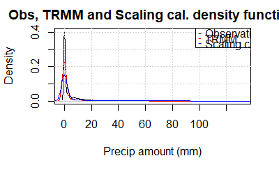

```r
legend("topright", legend = c("Observation","TRMM", "Scaling calibration"), pch ='-', col = c("black", "red", "blue"))
```

```r
qqplot(obs.sansebastian$Data, trmm.sansebastian$Data, main = "Obs,TRMM and Scaling calibration QQplot", xlab = "Observed (mm)", ylab = "TRMM/Calibration (mm)", col = "red")

abline(a = 0, b = 1)
```

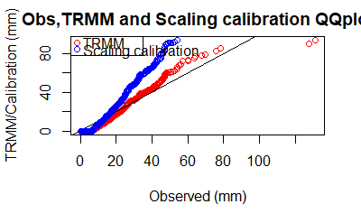

```r
points(sort(obs.sansebastian$Data), sort(cal.sansebastian.scaling$Data), col = "blue")

legend("topleft", legend = c("TRMM", "Scaling calibration"), pch = 1, col = c("red", "blue"))
```

```r
plot(density(obs.sansebastian$Data, na.rm = TRUE),
main = "Obs, TRMM and EQM cal. density function",
xlab = "Precip amount (mm)")
grid()
```

```r
lines(density(trmm.sansebastian$Data, na.rm = TRUE), col = "red")
lines(density(cal.sansebastian.eqm$Data, na.rm = TRUE), col = "blue")
```

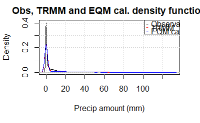

```r
legend("topright", legend = c("Observation","TRMM", "EQM calibration"), pch ='-', col = c("black", "red", "blue"))
```

```r
qqplot(obs.sansebastian$Data, trmm.sansebastian$Data, main = "Obs,TRMM and EQM calibration QQplot", xlab = "Observed (mm)", ylab = "TRMM/Calibration (mm)", col = "red")

abline(a = 0, b = 1)
```

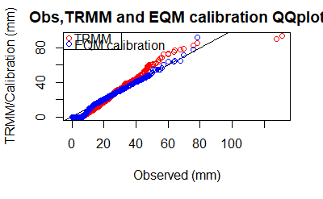

```r
points(sort(obs.sansebastian$Data), sort(cal.sansebastian.eqm$Data), col = "blue")

legend("topleft", legend = c("TRMM", "EQM calibration"), pch = 1, col = c("red", "blue"))
```

```r
plot(density(obs.sansebastian$Data, na.rm = TRUE),
main = "Obs, TRMM and EQM extrapol cal. density function",
xlab = "Precip amount (mm)")
grid()
```

```r
lines(density(trmm.sansebastian$Data, na.rm = TRUE), col = "red")
lines(density(cal.sansebastian.eqm.extrapol$Data, na.rm = TRUE), col = "blue")
```

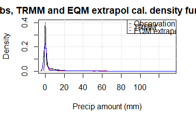

```r
legend("topright", legend = c("Observation","TRMM", "EQM extrapol calibration"), pch ='-', col = c("black", "red", "blue"))
```

```r
qqplot(obs.sansebastian$Data, trmm.sansebastian$Data, main = "Obs,TRMM and EQM extrapol calibration QQplot", xlab = "Observed (mm)", ylab = "TRMM/Calibration (mm)", col = "red")

abline(a = 0, b = 1)
```

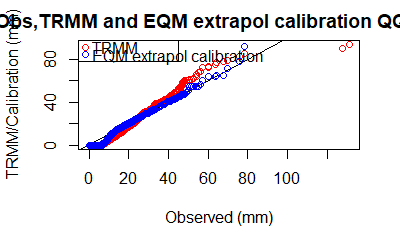

```r
points(sort(obs.sansebastian$Data), sort(cal.sansebastian.eqm.extrapol$Data), col = "blue")

legend("topleft", legend = c("TRMM", "EQM extrapol calibration"), pch = 1, col = c("red", "blue"))
```

```r
plot(density(obs.sansebastian$Data, na.rm = TRUE),
main = "Obs, TRMM and PQM cal. density function",
xlab = "Precip amount (mm)")
grid()
```

```r
lines(density(trmm.sansebastian$Data, na.rm = TRUE), col = "red")
lines(density(cal.sansebastian.pqm$Data, na.rm = TRUE), col = "blue")
```

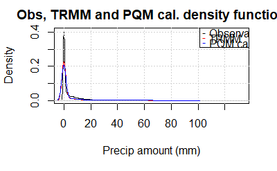

```r
legend("topright", legend = c("Observation","TRMM", "PQM calibration"), pch ='-', col = c("black", "red", "blue"))
```

```r
qqplot(obs.sansebastian$Data, trmm.sansebastian$Data, main = "Obs,TRMM and PQM calibration QQplot", xlab = "Observed (mm)", ylab = "TRMM/Calibration (mm)", col = "red")

abline(a = 0, b = 1)
```

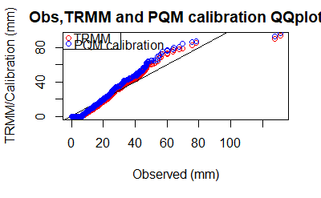

```r
points(sort(obs.sansebastian$Data), sort(cal.sansebastian.pqm$Data), col = "blue")

legend("topleft", legend = c("TRMM", "PQM calibration"), pch = 1, col = c("red", "blue"))
```

```r
plot(density(obs.sansebastian$Data, na.rm = TRUE),
main = "Obs, TRMM and GPQM cal. density function",
xlab = "Precip amount (mm)")
grid()
```

```r
lines(density(trmm.sansebastian$Data, na.rm = TRUE), col = "red")
lines(density(cal.sansebastian.gpqm$Data, na.rm = TRUE), col = "blue")
```

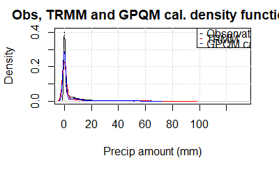

```r
legend("topright", legend = c("Observation","TRMM", "GPQM calibration"), pch ='-', col = c("black", "red", "blue"))
```

```r
qqplot(obs.sansebastian$Data, trmm.sansebastian$Data, main = "Obs,TRMM and GPQM calibration QQplot", xlab = "Observed (mm)", ylab = "TRMM/Calibration (mm)", col = "red")

abline(a = 0, b = 1)
```

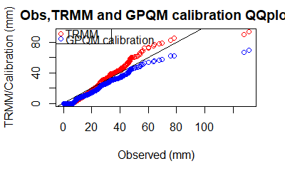

```r
points(sort(obs.sansebastian$Data), sort(cal.sansebastian.gpqm$Data), col = "blue")

legend("topleft", legend = c("TRMM", "GPQM calibration"), pch = 1, col = c("red", "blue"))
```

We can conclude that for 3 of the 4 stations, EQM is the best approach getting great results. Calibration methods have been shown necessary for precipitation study with TRMM remote sensing. Scaling and PQM in general give good results too. It seems that the index with worse approach in this calibration is P98WetAmount. The rest of the indices with calibration methods applied have a good approximation in general.The next steps could be to look at which methods overestimate the values of observations and which underestimate them.

# Navacerrada

```r
obs.navacerrada <- subsetGrid(obs, station.id = obs$Metadata$station_id[5])
idx <- which.min(abs(trmm$xyCoords$x - obs.navacerrada$xyCoords$x))
lon <- trmm$xyCoords$x[idx]

idx2 <- which.min(abs(trmm$xyCoords$y - obs.navacerrada$xyCoords$y))
lat <- trmm$xyCoords$y[idx2]

trmm.navacerrada <- subsetGrid(trmm, lonLim = lon, latLim = lat)

index.obs.navacerrada.rv13max <- MaxReturnValue(obs.navacerrada)
index.trmm.navacerrada.rv13max <- MaxReturnValue(trmm.navacerrada)


index.obs.navacerrada <- valueIndex1D(obs.navacerrada$Data,index.codes=c("Skewness","R10","R10p","R20","R20p","P98Wet","P98WetAmount"))

index.trmm.navacerrada <- valueIndex1D(trmm.navacerrada$Data,index.codes=c("Skewness","R10","R10p","R20","R20p","P98Wet","P98WetAmount"))


cal.navacerrada.scaling <- biasCorrection(y = obs.navacerrada, x = trmm.navacerrada, newdata = trmm.navacerrada, precipitation = TRUE, cross.val = "loo", method = "scaling", scaling.type = "multiplicative")

cal.navacerrada.scaling$Dates$start <- as.POSIXct(cal.navacerrada.scaling$Dates$start,tz = "GMT")
cal.navacerrada.scaling$Dates$end <- as.POSIXct(cal.navacerrada.scaling$Dates$end,tz = "GMT")

index.cal.navacerrada.scaling.rv13max <- MaxReturnValue(cal.navacerrada.scaling)

index.cal.navacerrada.scaling <- valueIndex1D(cal.navacerrada.scaling$Data,index.codes=c("Skewness","R10","R10p","R20","R20p","P98Wet","P98WetAmount"))

cal.navacerrada.eqm <- biasCorrection(y = obs.navacerrada, x = trmm.navacerrada, newdata = trmm.navacerrada, precipitation = TRUE, cross.val = "loo", method = "eqm")

cal.navacerrada.eqm$Dates$start <- as.POSIXct(cal.navacerrada.eqm$Dates$start,tz = "GMT")
cal.navacerrada.eqm$Dates$end <- as.POSIXct(cal.navacerrada.eqm$Dates$end,tz = "GMT")

index.cal.navacerrada.eqm.rv13max <- MaxReturnValue(cal.navacerrada.eqm)


index.cal.navacerrada.eqm <- valueIndex1D(cal.navacerrada.eqm$Data,index.codes=c("Skewness","R10","R10p","R20","R20p","P98Wet","P98WetAmount"))

cal.navacerrada.eqm.extrapol <- biasCorrection(y = obs.navacerrada, x = trmm.navacerrada, newdata = trmm.navacerrada, precipitation = TRUE, cross.val = "loo", method = "eqm",extrapolation = "constant")

cal.navacerrada.eqm.extrapol$Dates$start <- as.POSIXct(cal.navacerrada.eqm.extrapol$Dates$start,tz = "GMT")
cal.navacerrada.eqm.extrapol$Dates$end <- as.POSIXct(cal.navacerrada.eqm.extrapol$Dates$end,tz = "GMT")

index.cal.navacerrada.eqm.extrapol.rv13max <- MaxReturnValue(cal.navacerrada.eqm.extrapol)

index.cal.navacerrada.eqm.extrapol <- valueIndex1D(cal.navacerrada.eqm.extrapol$Data,index.codes=c("Skewness","R10","R10p","R20","R20p","P98Wet","P98WetAmount"))

cal.navacerrada.pqm <- biasCorrection(y = obs.navacerrada, x = trmm.navacerrada, newdata = trmm.navacerrada, precipitation = TRUE, cross.val = "loo", method = "pqm",  fitdistr.args = list(densfun = "gamma"))

cal.navacerrada.pqm$Dates$start <- as.POSIXct(cal.navacerrada.pqm$Dates$start,tz = "GMT")
cal.navacerrada.pqm$Dates$end <- as.POSIXct(cal.navacerrada.pqm$Dates$end,tz = "GMT")

index.cal.navacerrada.pqm.rv13max <- MaxReturnValue(cal.navacerrada.pqm)

index.cal.navacerrada.pqm <- valueIndex1D(cal.navacerrada.pqm$Data,index.codes=c("Skewness","R10","R10p","R20","R20p","P98Wet","P98WetAmount"))

cal.navacerrada.gpqm <- biasCorrection(y = obs.navacerrada, x = trmm.navacerrada, newdata = trmm.navacerrada, precipitation = TRUE, cross.val = "loo", method = "gpqm", theta = 0.7)
```

[output not shown]

```r
cal.navacerrada.gpqm$Dates$start <- as.POSIXct(cal.navacerrada.gpqm$Dates$start,tz = "GMT")
cal.navacerrada.gpqm$Dates$end <- as.POSIXct(cal.navacerrada.gpqm$Dates$end,tz = "GMT")

index.cal.navacerrada.gpqm.rv13max <- MaxReturnValue(cal.navacerrada.gpqm)

index.cal.navacerrada.gpqm <- valueIndex1D(cal.navacerrada.gpqm$Data,index.codes=c("Skewness","R10","R10p","R20","R20p","P98Wet","P98WetAmount"))
```

```r
index.obs.navacerrada <- c(index.obs.navacerrada,index.obs.navacerrada.rv13max)
index.trmm.navacerrada <- c(index.trmm.navacerrada,index.trmm.navacerrada.rv13max)
index.cal.navacerrada.scaling <- c(index.cal.navacerrada.scaling,index.cal.navacerrada.scaling.rv13max)
index.cal.navacerrada.eqm <- c(index.cal.navacerrada.eqm,index.cal.navacerrada.eqm.extrapol.rv13max)
index.cal.navacerrada.eqm.extrapol <- c(index.cal.navacerrada.eqm.extrapol,index.cal.navacerrada.eqm.extrapol.rv13max)
index.cal.navacerrada.pqm <- c(index.cal.navacerrada.pqm,index.cal.navacerrada.pqm.rv13max)
index.cal.navacerrada.gpqm <- c(index.cal.navacerrada.gpqm,index.cal.navacerrada.gpqm.rv13max)

results.navacerrada <- data.frame(index.obs.navacerrada, index.trmm.navacerrada, index.cal.navacerrada.scaling,
                      index.cal.navacerrada.eqm,index.cal.navacerrada.eqm.extrapol, index.cal.navacerrada.pqm, index.cal.navacerrada.gpqm
                      )
colnames(results.navacerrada) <- c("Obs","TRMM","Scaling cal.", "EQM cal.","EQM extrapol cal.", "PQM cal.","GPQM cal.")

results.navacerrada <- format(results.navacerrada, digits = 3, scientific = 5)

results.navacerrada
```

|  | Obs | TRMM | Scaling cal. | EQM cal. | EQM extrapol cal. | PQM cal. | GPQM cal. |
| --- | --- | --- | --- | --- | --- | --- | --- |
| Skewness | 4.0585 | 5.0179 | 5.0091 | 3.9754 | 4.1809 | 5.3265 | 4.2223 |
| R10 | 0.1139 | 0.0457 | 0.0986 | 0.1173 | 0.1173 | 0.1024 | 0.1194 |
| R10p | 12236.0000 | 4130.0571 | 10910.4532 | 12618.4712 | 12650.6847 | 12132.2977 | 11637.6784 |
| R20 | 0.0478 | 0.0156 | 0.0421 | 0.0495 | 0.0495 | 0.0442 | 0.0423 |
| R20p | 7783.6000 | 2105.0923 | 7175.6137 | 8057.0038 | 8089.2173 | 8212.3428 | 6691.6813 |
| P98Wet | 47.9600 | 27.7721 | 48.7832 | 48.1559 | 48.1559 | 56.5943 | 44.5323 |
| P98WetAmount | 1862.1000 | 1054.2914 | 2206.1667 | 1867.0639 | 1899.2774 | 2231.8005 | 1687.3855 |
| WetAnnualMaxSpell | 10.0000 | 9.0000 | 10.0000 | 9.0000 | 9.0000 | 9.0000 | 9.0000 |
| RV20_max | 86.0299 | 63.9603 | 115.8247 | 103.8727 | 103.8727 | 133.9014 | 95.6406 |

```r
NA
```

```r
 diff.navacerrada <- data.frame(abs(index.trmm.navacerrada-index.obs.navacerrada),abs(index.cal.navacerrada.scaling-index.obs.navacerrada),
                      abs(index.cal.navacerrada.eqm-index.obs.navacerrada),abs(index.cal.navacerrada.eqm.extrapol-index.obs.navacerrada), abs(index.cal.navacerrada.pqm-index.obs.navacerrada), abs(index.cal.navacerrada.gpqm-index.obs.navacerrada)
                      )
colnames(diff.navacerrada) <- c("TRMM","Scaling cal.", "EQM cal.","EQM extrapol cal.", "PQM cal.","GPQM cal.")

diff.navacerrada <- format(diff.navacerrada, digits = 3, scientific = 5)

diff.navacerrada
```

|  | TRMM | Scaling cal. | EQM cal. | EQM extrapol cal. | PQM cal. | GPQM cal. |
| --- | --- | --- | --- | --- | --- | --- |
| Skewness | 0.9593 | 0.95053 | 0.08313 | 0.12240 | 1.26792 | 0.16376 |
| R10 | 0.0682 | 0.01537 | 0.00337 | 0.00337 | 0.01158 | 0.00548 |
| R10p | 8105.9429 | 1325.54678 | 382.47121 | 414.68471 | 103.70229 | 598.32156 |
| R20 | 0.0322 | 0.00569 | 0.00168 | 0.00168 | 0.00358 | 0.00548 |
| R20p | 5678.5077 | 607.98634 | 273.40383 | 305.61733 | 428.74278 | 1091.91874 |
| P98Wet | 20.1879 | 0.82324 | 0.19591 | 0.19591 | 8.63434 | 3.42768 |
| P98WetAmount | 807.8086 | 344.06668 | 4.96387 | 37.17737 | 369.70052 | 174.71453 |
| WetAnnualMaxSpell | 1.0000 | 0.00000 | 1.00000 | 1.00000 | 1.00000 | 1.00000 |
| RV20_max | 22.0696 | 29.79476 | 17.84283 | 17.84283 | 47.87149 | 9.61067 |

```r
 diff.navacerrada.noabs <- data.frame(index.trmm.navacerrada-index.obs.navacerrada,index.cal.navacerrada.scaling-index.obs.navacerrada,
                      index.cal.navacerrada.eqm-index.obs.navacerrada, index.cal.navacerrada.eqm.extrapol-index.obs.navacerrada, index.cal.navacerrada.pqm-index.obs.navacerrada, index.cal.navacerrada.gpqm-index.obs.navacerrada)
colnames(diff.navacerrada.noabs) <- c("TRMM","Scaling_cal", "EQM_cal","EQM_cal.Extrapol", "PQM_cal","GPQM_cal")


formattable(diff.navacerrada.noabs, list(
  'TRMM' = formatter("span",
                         style = ~style(font.weight = "bold", color =
                                          ifelse(TRMM > 0,"red",
                                                 ifelse(TRMM == 0,"black",
                                                        ifelse(TRMM <0, "blue",NA))))),
  'Scaling_cal' = formatter("span",
                          style = ~style(font.weight = "bold", color =
                                           ifelse(Scaling_cal > 0,"red",
                                                  ifelse(Scaling_cal == 0,"black",
                                                         ifelse(Scaling_cal <0, "blue",NA))))),

   'EQM_cal' = formatter("span",
                          style = ~style(font.weight = "bold", color =
                                           ifelse(EQM_cal > 0,"red",
                                                  ifelse(EQM_cal == 0,"black",
                                                         ifelse(EQM_cal <0, "blue",NA))))),
   'EQM_cal.Extrapol' = formatter("span",
                         style = ~style(font.weight = "bold", color =
                                           ifelse(EQM_cal.Extrapol > 0,"red",
                                                  ifelse(EQM_cal.Extrapol == 0,"black",
                                                         ifelse(EQM_cal.Extrapol <0, "blue",NA))))),
   'PQM_cal' = formatter("span",
                          style = ~style(font.weight = "bold", color =
                                           ifelse(PQM_cal > 0,"red",
                                                  ifelse(PQM_cal == 0,"black",
                                                         ifelse(PQM_cal <0, "blue",NA))))),
   'GPQM_cal' = formatter("span",
                          style = ~style(font.weight = "bold", color =
                                           ifelse(GPQM_cal > 0,"red",
                                                  ifelse(GPQM_cal == 0,"black",
                                                         ifelse(GPQM_cal <0, "blue",NA)))))
 ))
```

|  | TRMM | Scaling_cal | EQM_cal | EQM_cal.Extrapol | PQM_cal | GPQM_cal |
| --- | --- | --- | --- | --- | --- | --- |
| Skewness | 9.593358e-01 | 9.505348e-01 | -0.08312775 | 0.12239912 | 1.267918e+00 | 1.637638e-01 |
| R10 | -6.823926e-02 | -1.537489e-02 | 0.00336984 | 0.00336984 | -1.158382e-02 | 5.475990e-03 |
| R10p | -8.105943e+03 | -1.325547e+03 | 382.47121187 | 414.68471198 | -1.037023e+02 | -5.983216e+02 |
| R20 | -3.222409e-02 | -5.686605e-03 | 0.00168492 | 0.00168492 | -3.580455e-03 | -5.475990e-03 |
| R20p | -5.678508e+03 | -6.079863e+02 | 273.40383035 | 305.61733046 | 4.287428e+02 | -1.091919e+03 |
| P98Wet | -2.018789e+01 | 8.232407e-01 | 0.19591297 | 0.19591297 | 8.634336e+00 | -3.427682e+00 |
| P98WetAmount | -8.078086e+02 | 3.440667e+02 | 4.96386572 | 37.17736583 | 3.697005e+02 | -1.747145e+02 |
| WetAnnualMaxSpell | -1.000000e+00 | 0.000000e+00 | -1.00000000 | -1.00000000 | -1.000000e+00 | -1.000000e+00 |
| RV20_max | -2.206963e+01 | 2.979476e+01 | 17.84282853 | 17.84282853 | 4.787149e+01 | 9.610667e+00 |

```r
plot(density(obs.navacerrada$Data, na.rm = TRUE),
main = "Obs, TRMM and Scaling cal. density function",
xlab = "Precip amount (mm)")
grid()
```

```r
lines(density(trmm.navacerrada$Data, na.rm = TRUE), col = "red")
lines(density(cal.navacerrada.scaling$Data, na.rm = TRUE), col = "blue")
```

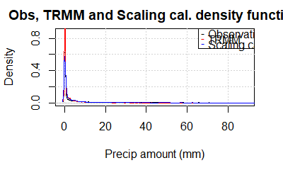

```r
legend("topright", legend = c("Observation","TRMM", "Scaling calibration"), pch ='-', col = c("black", "red", "blue"))
```

```r
qqplot(obs.navacerrada$Data, trmm.navacerrada$Data, main = "Obs,TRMM and Scaling calibration QQplot", xlab = "Observed (mm)", ylab = "TRMM/Calibration (mm)", col = "red")

abline(a = 0, b = 1)
```

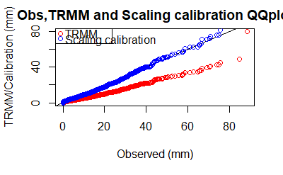

```r
points(sort(obs.navacerrada$Data), sort(cal.navacerrada.scaling$Data), col = "blue")

legend("topleft", legend = c("TRMM", "Scaling calibration"), pch = 1, col = c("red", "blue"))
```

```r
plot(density(obs.navacerrada$Data, na.rm = TRUE),
main = "Obs, TRMM and EQM cal. density function",
xlab = "Precip amount (mm)")
grid()
```

```r
lines(density(trmm.navacerrada$Data, na.rm = TRUE), col = "red")
lines(density(cal.navacerrada.eqm$Data, na.rm = TRUE), col = "blue")
```

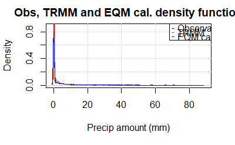

```r
legend("topright", legend = c("Observation","TRMM", "EQM calibration"), pch ='-', col = c("black", "red", "blue"))
```

```r
qqplot(obs.navacerrada$Data, trmm.navacerrada$Data, main = "Obs,TRMM and EQM calibration QQplot", xlab = "Observed (mm)", ylab = "TRMM/Calibration (mm)", col = "red")

abline(a = 0, b = 1)
```

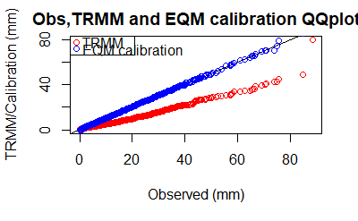

```r
points(sort(obs.navacerrada$Data), sort(cal.navacerrada.eqm$Data), col = "blue")

legend("topleft", legend = c("TRMM", "EQM calibration"), pch = 1, col = c("red", "blue"))
```

```r
plot(density(obs.navacerrada$Data, na.rm = TRUE),
main = "Obs, TRMM and EQM extrapol cal. density function",
xlab = "Precip amount (mm)")
grid()
```

```r
lines(density(trmm.navacerrada$Data, na.rm = TRUE), col = "red")
lines(density(cal.navacerrada.eqm.extrapol$Data, na.rm = TRUE), col = "blue")
```

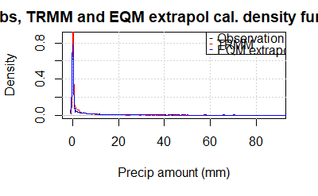

```r
legend("topright", legend = c("Observation","TRMM", "EQM extrapol calibration"), pch ='-', col = c("black", "red", "blue"))
```

```r
qqplot(obs.navacerrada$Data, trmm.navacerrada$Data, main = "Obs,TRMM and EQM extrapol calibration QQplot", xlab = "Observed (mm)", ylab = "TRMM/Calibration (mm)", col = "red")

abline(a = 0, b = 1)
```

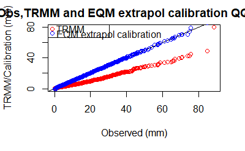

```r
points(sort(obs.navacerrada$Data), sort(cal.navacerrada.eqm.extrapol$Data), col = "blue")

legend("topleft", legend = c("TRMM", "EQM extrapol calibration"), pch = 1, col = c("red", "blue"))
```

```r
plot(density(obs.navacerrada$Data, na.rm = TRUE),
main = "Obs, TRMM and PQM cal. density function",
xlab = "Precip amount (mm)")
grid()
```

```r
lines(density(trmm.navacerrada$Data, na.rm = TRUE), col = "red")
lines(density(cal.navacerrada.pqm$Data, na.rm = TRUE), col = "blue")
```

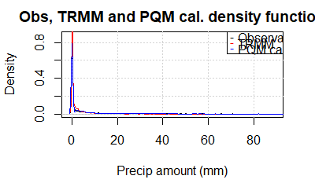

```r
legend("topright", legend = c("Observation","TRMM", "PQM calibration"), pch ='-', col = c("black", "red", "blue"))
```

```r
qqplot(obs.navacerrada$Data, trmm.navacerrada$Data, main = "Obs,TRMM and PQM calibration QQplot", xlab = "Observed (mm)", ylab = "TRMM/Calibration (mm)", col = "red")

abline(a = 0, b = 1)
```

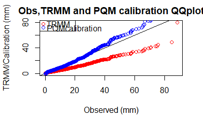

```r
points(sort(obs.navacerrada$Data), sort(cal.navacerrada.pqm$Data), col = "blue")

legend("topleft", legend = c("TRMM", "PQMcalibration"), pch = 1, col = c("red", "blue"))
```

```r
plot(density(obs.navacerrada$Data, na.rm = TRUE),
main = "Obs, TRMM and GPQM cal. density function",
xlab = "Precip amount (mm)")
grid()
```

```r
lines(density(trmm.navacerrada$Data, na.rm = TRUE), col = "red")
lines(density(cal.navacerrada.gpqm$Data, na.rm = TRUE), col = "blue")
```

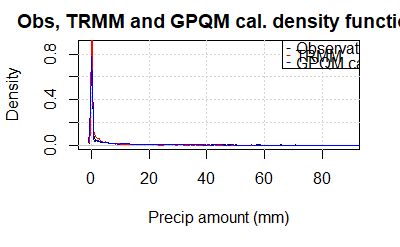

```r
legend("topright", legend = c("Observation","TRMM", "GPQM calibration"), pch ='-', col = c("black", "red", "blue"))
```

```r
qqplot(obs.navacerrada$Data, trmm.navacerrada$Data, main = "Obs,TRMM and GPQM calibration QQplot", xlab = "Observed (mm)", ylab = "TRMM/Calibration (mm)", col = "red")

abline(a = 0, b = 1)
```

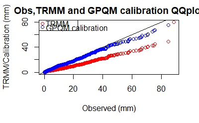

```r
points(sort(obs.navacerrada$Data), sort(cal.navacerrada.gpqm$Data), col = "blue")

legend("topleft", legend = c("TRMM", "GPQM calibration"), pch = 1, col = c("red", "blue"))
```

# Santiago de Compostela

```r
obs.santiago <- subsetGrid(obs, station.id = obs$Metadata$station_id[9])
idx <- which.min(abs(trmm$xyCoords$x - obs.santiago$xyCoords$x))
lon <- trmm$xyCoords$x[idx]

idx2 <- which.min(abs(trmm$xyCoords$y - obs.santiago$xyCoords$y))
lat <- trmm$xyCoords$y[idx2]

trmm.santiago <- subsetGrid(trmm, lonLim = lon, latLim = lat)

index.obs.santiago <- valueIndex1D(obs.santiago$Data,index.codes=c("Skewness","R10","R10p","R20","R20p","P98Wet","P98WetAmount"))

index.trmm.santiago <- valueIndex1D(trmm.santiago$Data,index.codes=c("Skewness","R10","R10p","R20","R20p","P98Wet","P98WetAmount"))

index.obs.santiago.rv13max <- MaxReturnValue(obs.santiago)
index.trmm.santiago.rv13max <- MaxReturnValue(trmm.santiago)


cal.santiago.scaling <- biasCorrection(y = obs.santiago, x = trmm.santiago, newdata = trmm.santiago, precipitation = TRUE, cross.val = "loo", method = "scaling", scaling.type = "multiplicative")

cal.santiago.scaling$Dates$start <- as.POSIXct(cal.santiago.scaling$Dates$start,tz = "GMT")
cal.santiago.scaling$Dates$end <- as.POSIXct(cal.santiago.scaling$Dates$end,tz = "GMT")

index.cal.santiago.scaling.rv13max <- MaxReturnValue(cal.santiago.scaling)

index.cal.santiago.scaling <- valueIndex1D(cal.santiago.scaling$Data,index.codes=c("Skewness","R10","R10p","R20","R20p","P98Wet","P98WetAmount"))

cal.santiago.eqm <- biasCorrection(y = obs.santiago, x = trmm.santiago, newdata = trmm.santiago, precipitation = TRUE, cross.val = "loo", method = "eqm")

cal.santiago.eqm$Dates$start <- as.POSIXct(cal.santiago.eqm$Dates$start,tz = "GMT")
cal.santiago.eqm$Dates$end <- as.POSIXct(cal.santiago.eqm$Dates$end,tz = "GMT")

index.cal.santiago.eqm.rv13max <- MaxReturnValue(cal.santiago.eqm)

index.cal.santiago.eqm <- valueIndex1D(cal.santiago.eqm$Data,index.codes=c("Skewness","R10","R10p","R20","R20p","P98Wet","P98WetAmount"))

cal.santiago.eqm.extrapol <- biasCorrection(y = obs.santiago, x = trmm.santiago, newdata = trmm.santiago, precipitation = TRUE, cross.val = "loo", method = "eqm", extrapolation = "constant")

cal.santiago.eqm.extrapol$Dates$start <- as.POSIXct(cal.santiago.eqm.extrapol$Dates$start,tz = "GMT")
cal.santiago.eqm.extrapol$Dates$end <- as.POSIXct(cal.santiago.eqm.extrapol$Dates$end,tz = "GMT")

index.cal.santiago.eqm.extrapol.rv13max <- MaxReturnValue(cal.santiago.eqm.extrapol)


index.cal.santiago.eqm.extrapol <- valueIndex1D(cal.santiago.eqm.extrapol$Data,index.codes=c("Skewness","R10","R10p","R20","R20p","P98Wet","P98WetAmount"))

cal.santiago.pqm <- biasCorrection(y = obs.santiago, x = trmm.santiago, newdata = trmm.santiago, precipitation = TRUE, cross.val = "loo", method = "pqm",  fitdistr.args = list(densfun = "gamma"))

cal.santiago.pqm$Dates$start <- as.POSIXct(cal.santiago.pqm$Dates$start,tz = "GMT")
cal.santiago.pqm$Dates$end <- as.POSIXct(cal.santiago.pqm$Dates$end,tz = "GMT")

index.cal.santiago.pqm.rv13max <- MaxReturnValue(cal.santiago.pqm)

index.cal.santiago.pqm <- valueIndex1D(cal.santiago.pqm$Data,index.codes=c("Skewness","R10","R10p","R20","R20p","P98Wet","P98WetAmount"))

cal.santiago.gpqm <- biasCorrection(y = obs.santiago, x = trmm.santiago, newdata = trmm.santiago, precipitation = TRUE, cross.val = "loo", method = "gpqm", theta = 0.7)
```

[output not shown]

```r
cal.santiago.gpqm$Dates$start <- as.POSIXct(cal.santiago.gpqm$Dates$start,tz = "GMT")
cal.santiago.gpqm$Dates$end <- as.POSIXct(cal.santiago.gpqm$Dates$end,tz = "GMT")

index.cal.santiago.gpqm.rv13max <- MaxReturnValue(cal.santiago.gpqm)

index.cal.santiago.gpqm <- valueIndex1D(cal.santiago.gpqm$Data,index.codes=c("Skewness","R10","R10p","R20","R20p","P98Wet","P98WetAmount"))
```

```r
index.obs.santiago <- c(index.obs.santiago,index.obs.santiago.rv13max)
index.trmm.santiago <- c(index.trmm.santiago,index.trmm.santiago.rv13max)
index.cal.santiago.scaling <- c(index.cal.santiago.scaling,index.cal.santiago.scaling.rv13max)
index.cal.santiago.eqm <- c(index.cal.santiago.eqm,index.cal.santiago.eqm.rv13max)
index.cal.santiago.eqm.extrapol <- c(index.cal.santiago.eqm.extrapol,index.cal.santiago.eqm.extrapol.rv13max)
index.cal.santiago.pqm <- c(index.cal.santiago.pqm,index.cal.santiago.pqm.rv13max)
index.cal.santiago.gpqm <- c(index.cal.santiago.gpqm,index.cal.santiago.gpqm.rv13max)

results.santiago <- data.frame(index.obs.santiago, index.trmm.santiago, index.cal.santiago.scaling,
                      index.cal.santiago.eqm,index.cal.santiago.eqm.extrapol, index.cal.santiago.pqm, index.cal.santiago.gpqm
                      )
colnames(results.santiago) <- c("Obs","TRMM","Scaling cal.", "EQM cal.","EQM extrapol cal.", "PQM cal.","GPQM cal.")

results.santiago <- format(results.santiago, digits = 3, scientific = 5)

results.santiago
```

|  | Obs | TRMM | Scaling cal. | EQM cal. | EQM extrapol cal. | PQM cal. | GPQM cal. |
| --- | --- | --- | --- | --- | --- | --- | --- |
| Skewness | 3.4245 | 5.0224 | 5.0516 | 3.5607 | 3.7609 | 4.5027 | 4.1045 |
| R10 | 0.1620 | 0.1072 | 0.1230 | 0.1445 | 0.1447 | 0.1217 | 0.1224 |
| R10p | 18253.4000 | 15069.4886 | 20784.1676 | 17451.3221 | 17516.5030 | 16820.1465 | 12692.8541 |
| R20 | 0.0754 | 0.0628 | 0.0796 | 0.0765 | 0.0765 | 0.0718 | 0.0461 |
| R20p | 12484.0000 | 12025.0887 | 17763.8350 | 12686.6483 | 12727.0296 | 13382.4073 | 7553.1236 |
| P98Wet | 54.4760 | 72.7467 | 96.4211 | 63.6008 | 63.5856 | 71.9779 | 52.0334 |
| P98WetAmount | 2365.4000 | 2007.1445 | 2661.9115 | 1618.2830 | 1658.6643 | 2026.9348 | 1380.1220 |
| WetAnnualMaxSpell | 15.0000 | 7.0000 | 7.0000 | 7.0000 | 7.0000 | 7.0000 | 7.0000 |
| RV20_max | 107.5961 | 149.9215 | 198.9499 | 103.4884 | 110.4063 | 142.2663 | 96.9704 |

```r
NA
```

```r
 diff.santiago <- data.frame(abs(index.trmm.santiago-index.obs.santiago),abs(index.cal.santiago.scaling-index.obs.santiago),
                      abs(index.cal.santiago.eqm-index.obs.santiago),abs(index.cal.santiago.eqm.extrapol-index.obs.santiago), abs(index.cal.santiago.pqm-index.obs.santiago), abs(index.cal.santiago.gpqm-index.obs.santiago)
                      )
colnames(diff.santiago) <- c("TRMM","Scaling cal.", "EQM cal.","EQM extrapol cal.", "PQM cal.","GPQM cal.")

diff.santiago <- format(diff.santiago, digits = 3, scientific = 5)

diff.santiago
```

|  | TRMM | Scaling cal. | EQM cal. | EQM extrapol cal. | PQM cal. | GPQM cal. |
| --- | --- | --- | --- | --- | --- | --- |
| Skewness | 1.5979 | 1.62709 | 0.13620 | 0.33640 | 1.07813 | 0.6799 |
| R10 | 0.0548 | 0.03896 | 0.01748 | 0.01727 | 0.04023 | 0.0396 |
| R10p | 3183.9114 | 2530.76763 | 802.07791 | 736.89696 | 1433.25352 | 5560.5459 |
| R20 | 0.0126 | 0.00421 | 0.00105 | 0.00105 | 0.00358 | 0.0293 |
| R20p | 458.9113 | 5279.83496 | 202.64835 | 243.02959 | 898.40726 | 4930.8764 |
| P98Wet | 18.2707 | 41.94506 | 9.12475 | 9.10958 | 17.50193 | 2.4426 |
| P98WetAmount | 358.2555 | 296.51152 | 747.11698 | 706.73574 | 338.46522 | 985.2780 |
| WetAnnualMaxSpell | 8.0000 | 8.00000 | 8.00000 | 8.00000 | 8.00000 | 8.0000 |
| RV20_max | 42.3254 | 91.35371 | 4.10775 | 2.81018 | 34.67011 | 10.6257 |

```r
 diff.santiago.noabs <- data.frame(index.trmm.santiago-index.obs.santiago,index.cal.santiago.scaling-index.obs.santiago,
                      index.cal.santiago.eqm-index.obs.santiago, index.cal.santiago.eqm.extrapol-index.obs.santiago, index.cal.santiago.pqm-index.obs.santiago, index.cal.santiago.gpqm-index.obs.santiago)
colnames(diff.santiago.noabs) <- c("TRMM","Scaling_cal", "EQM_cal","EQM_cal.Extrapol", "PQM_cal","GPQM_cal")


formattable(diff.santiago.noabs, list(
  'TRMM' = formatter("span",
                         style = ~style(font.weight = "bold", color =
                                          ifelse(TRMM > 0,"red",
                                                 ifelse(TRMM == 0,"black",
                                                        ifelse(TRMM <0, "blue",NA))))),
  'Scaling_cal' = formatter("span",
                          style = ~style(font.weight = "bold", color =
                                           ifelse(Scaling_cal > 0,"red",
                                                  ifelse(Scaling_cal == 0,"black",
                                                         ifelse(Scaling_cal <0, "blue",NA))))),

   'EQM_cal' = formatter("span",
                          style = ~style(font.weight = "bold", color =
                                           ifelse(EQM_cal > 0,"red",
                                                  ifelse(EQM_cal == 0,"black",
                                                         ifelse(EQM_cal <0, "blue",NA))))),
   'EQM_cal.Extrapol' = formatter("span",
                         style = ~style(font.weight = "bold", color =
                                           ifelse(EQM_cal.Extrapol > 0,"red",
                                                  ifelse(EQM_cal.Extrapol == 0,"black",
                                                         ifelse(EQM_cal.Extrapol <0, "blue",NA))))),
   'PQM_cal' = formatter("span",
                          style = ~style(font.weight = "bold", color =
                                           ifelse(PQM_cal > 0,"red",
                                                  ifelse(PQM_cal == 0,"black",
                                                         ifelse(PQM_cal <0, "blue",NA))))),
   'GPQM_cal' = formatter("span",
                          style = ~style(font.weight = "bold", color =
                                           ifelse(GPQM_cal > 0,"red",
                                                  ifelse(GPQM_cal == 0,"black",
                                                         ifelse(GPQM_cal <0, "blue",NA)))))
 ))
```

|  | TRMM | Scaling_cal | EQM_cal | EQM_cal.Extrapol | PQM_cal | GPQM_cal |
| --- | --- | --- | --- | --- | --- | --- |
| Skewness | 1.5978712 | 1.62708987 | 1.362026e-01 | 3.363975e-01 | 1.078127e+00 | 6.799201e-01 |
| R10 | -0.0547599 | -0.03896377 | -1.748104e-02 | -1.727043e-02 | -4.022746e-02 | -3.959562e-02 |
| R10p | -3183.9113697 | 2530.76762905 | -8.020779e+02 | -7.368970e+02 | -1.433254e+03 | -5.560546e+03 |
| R20 | -0.0126369 | 0.00421230 | 1.053075e-03 | 1.053075e-03 | -3.580455e-03 | -2.927548e-02 |
| R20p | -458.9113007 | 5279.83495930 | 2.026483e+02 | 2.430296e+02 | 8.984073e+02 | -4.930876e+03 |
| P98Wet | 18.2707380 | 41.94506058 | 9.124754e+00 | 9.109579e+00 | 1.750193e+01 | -2.442557e+00 |
| P98WetAmount | -358.2554611 | 296.51152448 | -7.471170e+02 | -7.067357e+02 | -3.384652e+02 | -9.852780e+02 |
| WetAnnualMaxSpell | -8.0000000 | -8.00000000 | -8.000000e+00 | -8.000000e+00 | -8.000000e+00 | -8.000000e+00 |
| RV20_max | 42.3253655 | 91.35371332 | -4.107752e+00 | 2.810184e+00 | 3.467011e+01 | -1.062574e+01 |